# Prueba de Evaluación R

Diego Maquedano Pedrero

Noviembre 2021

# Pregunta 1

Este problema se puede resolver mediante el uso de una permutación, pues los números de la lotería para este ejemplo serán todas las posibles permutaciones de 4 elementos que se pueden formar con un vector formado por los números del 0 al 9.

Antes de comenzar, se comprueba que la librería a cargar esté instalada y, en caso contrario, proceder a instalarla con el siguiente código:

```r
comprobar <- function(pkg){
    new.pkg <- pkg[!(pkg %in% installed.packages()[, "Package"])]
    if (length(new.pkg))
        install.packages(new.pkg, dependencies = TRUE)
    sapply(pkg, require, character.only = TRUE)
}
paquetes<-c("gtools")

comprobar(paquetes)
```

```
## gtools
##   TRUE
```

### Apartado a)

En este caso se emplea la librería gtools que provee algunas funciones útiles en combinatoria, aunque también se podría usar combinat.

```r
# Cargar la librería
library(gtools)

# Definir vector con los dígitos del 0 al 9
vec <- c(0:9)

# ALmacenar en una variable todas las permutaciones posibles (se genera como una
# matriz y lo fuerzo a dataframe por comodidad en posteriores usos)
res<- as.data.frame(permutations(n= 10, r = 4, v = vec, repeats.allowed = TRUE))

# Como en cada columna viene un dígito, combino todas generando una nueva
# columna que las combina para dar lugar al número como tal

res$numero<-paste(res$V1,res$V2,res$V3,res$V4)

# Mostrar como resultado únicamente esta columna en forma de dataframe
res_final<-as.data.frame(res$numero)

# Colocar un nombre de columna más explicativo
colnames(res_final)<-c("Nums_Boletos")

# Mostrar los primeros 20 resultados del dataframe
head(res_final,20)
```

```
##    Nums_Boletos
## 1       0 0 0 0
## 2       0 0 0 1
## 3       0 0 0 2
## 4       0 0 0 3
## 5       0 0 0 4
## 6       0 0 0 5
## 7       0 0 0 6
## 8       0 0 0 7
## 9       0 0 0 8
## 10      0 0 0 9
## 11      0 0 1 0
## 12      0 0 1 1
## 13      0 0 1 2
## 14      0 0 1 3
## 15      0 0 1 4
## 16      0 0 1 5
## 17      0 0 1 6
## 18      0 0 1 7
## 19      0 0 1 8
## 20      0 0 1 9
```

```r
# O mostrarlos de manera más compacta sin el dataframe
res$numero
```

```
##     [1] "0 0 0 0" "0 0 0 1" "0 0 0 2" "0 0 0 3" "0 0 0 4" "0 0 0 5" "0 0 0 6"
##     [8] "0 0 0 7" "0 0 0 8" "0 0 0 9" "0 0 1 0" "0 0 1 1" "0 0 1 2" "0 0 1 3"
##    [15] "0 0 1 4" "0 0 1 5" "0 0 1 6" "0 0 1 7" "0 0 1 8" "0 0 1 9" "0 0 2 0"
##    [22] "0 0 2 1" "0 0 2 2" "0 0 2 3" "0 0 2 4" "0 0 2 5" "0 0 2 6" "0 0 2 7"
##    [29] "0 0 2 8" "0 0 2 9" "0 0 3 0" "0 0 3 1" "0 0 3 2" "0 0 3 3" "0 0 3 4"
##    [36] "0 0 3 5" "0 0 3 6" "0 0 3 7" "0 0 3 8" "0 0 3 9" "0 0 4 0" "0 0 4 1"
##    [43] "0 0 4 2" "0 0 4 3" "0 0 4 4" "0 0 4 5" "0 0 4 6" "0 0 4 7" "0 0 4 8"
##    [50] "0 0 4 9" "0 0 5 0" "0 0 5 1" "0 0 5 2" "0 0 5 3" "0 0 5 4" "0 0 5 5"
##    [57] "0 0 5 6" "0 0 5 7" "0 0 5 8" "0 0 5 9" "0 0 6 0" "0 0 6 1" "0 0 6 2"
##    [64] "0 0 6 3" "0 0 6 4" "0 0 6 5" "0 0 6 6" "0 0 6 7" "0 0 6 8" "0 0 6 9"
##    [71] "0 0 7 0" "0 0 7 1" "0 0 7 2" "0 0 7 3" "0 0 7 4" "0 0 7 5" "0 0 7 6"
##    [78] "0 0 7 7" "0 0 7 8" "0 0 7 9" "0 0 8 0" "0 0 8 1" "0 0 8 2" "0 0 8 3"
##    [85] "0 0 8 4" "0 0 8 5" "0 0 8 6" "0 0 8 7" "0 0 8 8" "0 0 8 9" "0 0 9 0"
##    [92] "0 0 9 1" "0 0 9 2" "0 0 9 3" "0 0 9 4" "0 0 9 5" "0 0 9 6" "0 0 9 7"
##    [99] "0 0 9 8" "0 0 9 9" "0 1 0 0" "0 1 0 1" "0 1 0 2" "0 1 0 3" "0 1 0 4"
```

[output cut: 1414 more lines]

### Apartado b)

Para este apartado se empleará el dataframe res del apartado anterior eliminando la columna de numero creada porque no es necesaria aquí.A continuación, se sumarán los valores de cada una de las columnas para pasar a obtener la moda de dicha columna (valor más repetido)

```r
# Borrar columna numero de res
res$numero<-NULL

# Crear la columna con la suma de las otras columnas
res$suma<-res$V1+res$V2+res$V3+res$V4

# Como no hay una función de moda definida se puede definir la siguiente
Mode <- function(x) {
  ux <- unique(x)
  ux[which.max(tabulate(match(x, ux)))]
}

# Se aplica la función a la columna del dataframe
print(paste("La suma que más se repite es: ",Mode(res$suma)))
```

```
## [1] "La suma que más se repite es:  18"
```

# Pregunta 2

### Apartado a)

Para importar los archivos en este problema, si se estuviera trabajando en un script ejecutable, se podría usar la función choose.files la cual permite elegir el archivo por parte del usuario sin tener un path predeterminado:

```r
#datos<-read.csv(choose.files())
```

Como no es el caso, se usará el directorio en el que tengo guardados los archivos y la función read.csv para los csv así como read.table para el txt:

```r
# Colocar el directorio donde están guardados los archivos para sólo poner el
# nombre al leerlos
setwd("C:/Users/Diego/Desktop/MASTER BIG DATA/Modulo_4_R/2.Tareas/TareaEvaluacion/Datos/Cod_19")

# Ir almacenando en sus respectivas variables el contenido de los archivos
provincias<-read.csv("datos_provincias.csv", sep=",", header=TRUE,
                     encoding = "UTF-8")

cod_prov<- read.table("CodProv.txt",sep =",", header = TRUE,
                      encoding = "UTF-8")

cod_CCAA<-read.csv("CodCCAA.csv", sep="\t", header=TRUE,
                     encoding = "UTF-8")
```

Una vez se tienen los datos en dataframes se debe hacer un merge de las provincias con cod_provincias para lo cual se hará una pequeña transformación en este último añadiendo una columna con el código de la provincia sin el prefijo

```r
# generar nueva columna sin el prefijo
cod_prov$provincia_iso<-gsub("ES-","",as.character(cod_prov$Código))
head(cod_prov)
```

```
##   Código Nombre.de.la.subdivisión.en.la.ISO1 Comunidad.autónoma provincia_iso
## 1   ES-C                            A Coruña                 GA             C
## 2  ES-VI                               Araba                 PV            VI
## 3  ES-AB                            Albacete                 CM            AB
## 4   ES-A                    Alicante/Alacant                 VC             A
## 5  ES-AL                             Almería                 AN            AL
## 6   ES-O                            Asturias                 AS             O
```

```r
# Hacer un merge del provincias por la columna provincia_iso con cod_prov
provincias<-merge(provincias,cod_prov,by="provincia_iso")

# Eliminar columnas innecesarias
provincias[ ,c('Nombre.de.la.subdivisión.en.la.ISO1', 'Código')] <- list(NULL)
head(provincias)
```

```
##   provincia_iso      fecha num_casos num_casos_prueba_pcr
## 1             A 2020-04-16        44                   21
## 2             A 2020-04-08        39                   30
## 3             A 2020-09-02       213                  213
## 4             A 2020-02-01         0                    0
## 5             A 2020-09-23         0                    0
## 6             A 2020-02-15         1                    1
##   num_casos_prueba_test_ac num_casos_prueba_otras num_casos_prueba_desconocida
## 1                       23                      0                            0
## 2                        9                      0                            0
## 3                        0                      0                            0
## 4                        0                      0                            0
## 5                        0                      0                            0
## 6                        0                      0                            0
##   Comunidad.autónoma
## 1                 VC
## 2                 VC
## 3                 VC
## 4                 VC
## 5                 VC
## 6                 VC
```

Una vez se tiene el dataframe, lo exportamos para tener el archivo datos_provincias con la nueva columna

```r
write.csv(provincias, "datos_provincias2.csv")
```

### Apartado b)

Mi DNI es 50649501M por lo que haciendo la transformación que se pide, la comunidad que me corresponde se obtendría como:

```r
my_codigo<-50649501%%17
cod_CCAA[cod_CCAA$X==my_codigo,]
```

```
##   Código Nombre.de.la.subdivisión.en.la.ISO1.U.200B. X
## 8  ES-CT                        Catalunya (Cataluña) 7
```

Sabiendo esto se filtrarán en el dataframe de provincias aquellas líneas cuyo código sea el de Cataluña

```r
# Obtener el substring
my_cod_prov<-gsub("ES-","",as.character(cod_CCAA[cod_CCAA$X==my_codigo,][1]))

# Filtrar por aquellas filas que lo contengan en provincias
my_data<-provincias[provincias$Comunidad.autónoma==my_cod_prov,]

# Comprobar que, efectivamente es así y no se han incluido otras comunidades
unique(my_data$Comunidad.autónoma)
```

```
## [1] "CT"
```

### Apartado c)

Echando un vistazo al dataset resultante, se comprueba que los datos están desagregados por provincias dentro de la comunidad autónoma, es decir, para una misma fecha, se dispone de los datos de varias provincias. Por ello, para tratar con el global de toda la comunidad de hará una agrupación por fecha de la num_casos:

```r
# Realizo la agregación en base a la columna de fecha sumando los casos
agregado<-as.data.frame(aggregate(my_data$num_casos~my_data$fecha,my_data,sum))

# Cambiar los nombres de las columnas
colnames(agregado)<-c("Fecha","Casos_Nuevos")

#Convertir a formato fecha la columna correspondiente
agregado$Fecha<-as.Date(agregado$Fecha)
```

Por último, se realiza el gráfico que podría ser tanto de líneas (evolución temporal) como de barras. Se elegirá este último porque se muestran mejor las cantidades en este tipo de gráficos. Además se importará la librería ggplot2 para crear visualizaciones más refinadas y con fases de creación mejor definidas

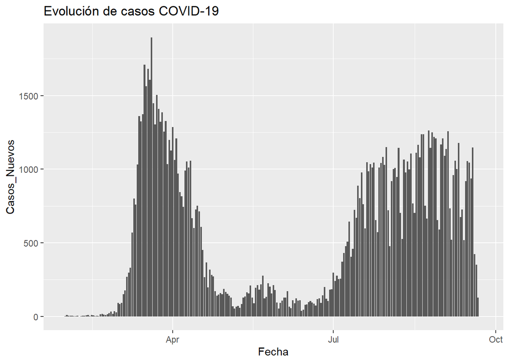

```r
# Cargamos la librería ggplot2 y creamos el gráfico de barras
library(ggplot2)
ggplot(data=agregado,aes(x=Fecha,y=Casos_Nuevos))+
  geom_bar(stat = "identity")+
  ggtitle("Evolución de casos COVID-19")
```

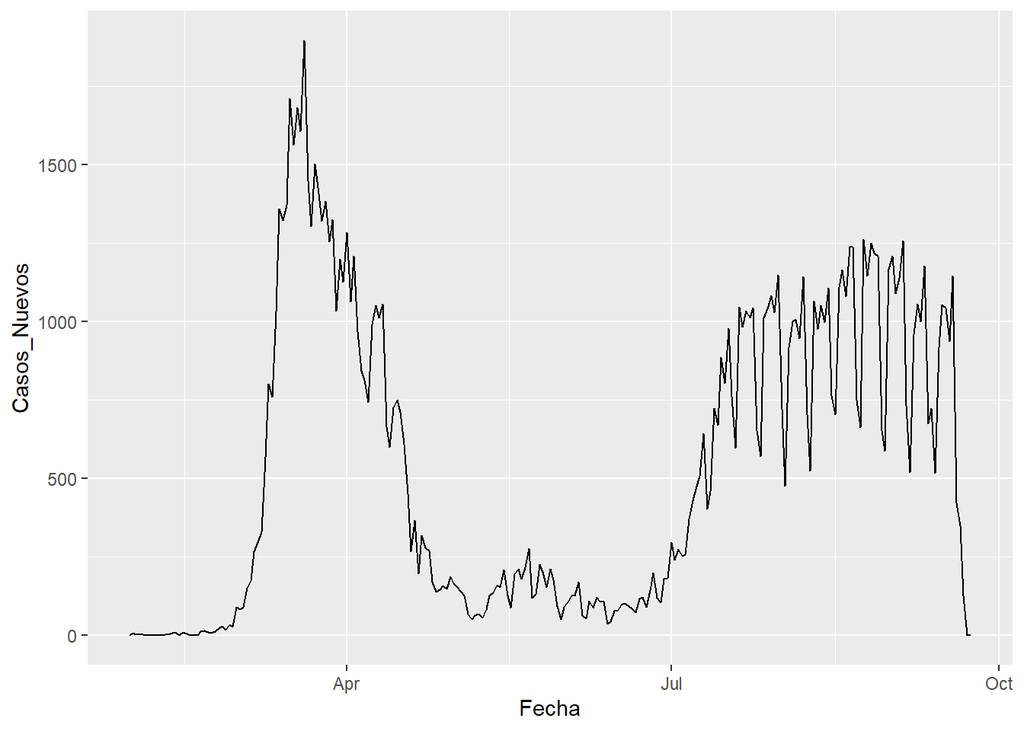

```r
# También se puede incluir el gráfico de líneas para comparar
ggplot(data=agregado,aes(x=Fecha,y=Casos_Nuevos))+
  geom_line()
```

### Apartado d)

Para poder hacer las múltiples líneas, se deberán agregar todas las columnas al igual que se ha hecho en el apartado anterior, exceptuendo aquellas de tipo character

```r
# Crear una lista que será el input de la función aggregate con las columnas
# que se van a agregar
cols_agregar<-list(my_data$num_casos,
                   my_data$num_casos_prueba_pcr,
                   my_data$num_casos_prueba_test_ac,
                   my_data$num_casos_prueba_otras,
                   my_data$num_casos_prueba_desconocida)

# Hacer el agregado por fecha
agregado_multiple<-as.data.frame(aggregate(cols_agregar, by=list(my_data$fecha),
                                           sum))

#Cambiar el nombre de las columnas para que sean más explicativos
colnames(agregado_multiple)<-c("Fecha","num_casos","num_casos_prueba_pcr",
                               "num_casos_prueba_test_ac",
                               "num_casos_prueba_otras",
                               "num_casos_prueba_desconocida")
# Poner la fecha como fecha
agregado_multiple$Fecha<-as.Date(agregado_multiple$Fecha)
```

Se crea el gráfico con una línea para cada columna con ggplot añadiendo nombres a los ejes y colocando la leyenda

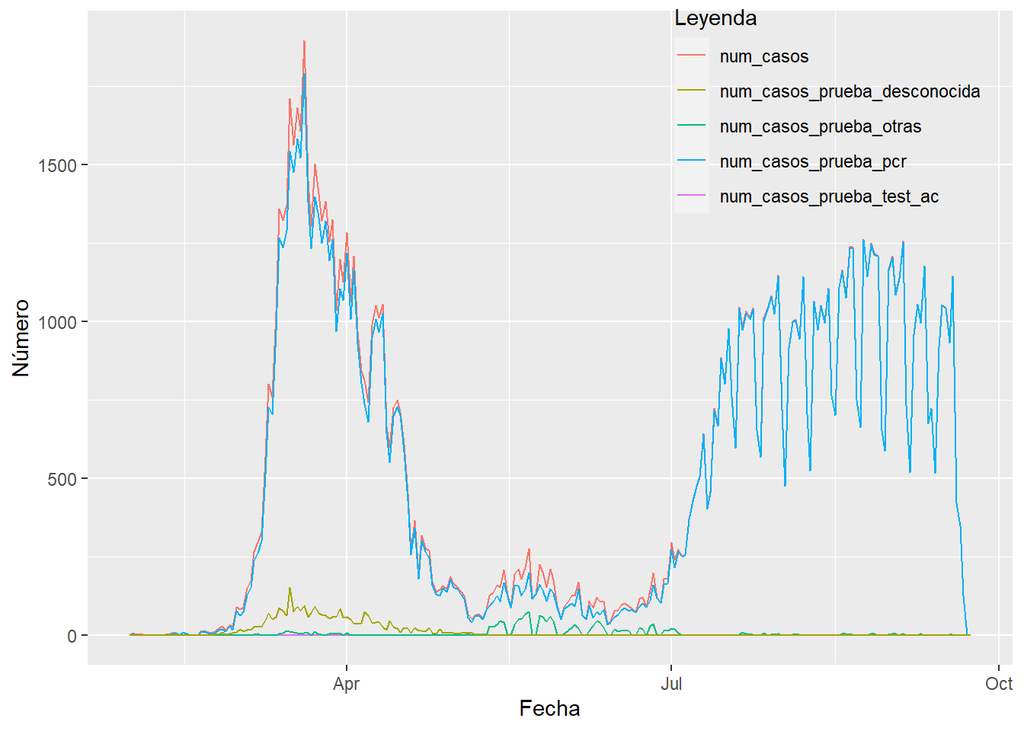

```r
ggplot(data=agregado_multiple, aes(x=Fecha)) +
  geom_line(aes(y = num_casos,colour="num_casos")) +
  geom_line(aes(y = num_casos_prueba_pcr,colour="num_casos_prueba_pcr"))+
  geom_line(aes(y = num_casos_prueba_test_ac,
                colour="num_casos_prueba_test_ac")) +

  geom_line(aes(y = num_casos_prueba_otras,colour="num_casos_prueba_otras"))+
  geom_line(aes(y = num_casos_prueba_desconocida,
                colour="num_casos_prueba_desconocida"))+

  labs(x="Fecha", y="Número",colour="Leyenda")+
  theme(legend.position = c(0.8,0.85),legend.background=element_blank())
```

# Pregunta 3

### Apartado a)

Para realizar el primero de los gráficos se puede volver a usar la librería ggplot2 empleando las variables hp y mpg como ejes y carb como color en un gráfico de puntos

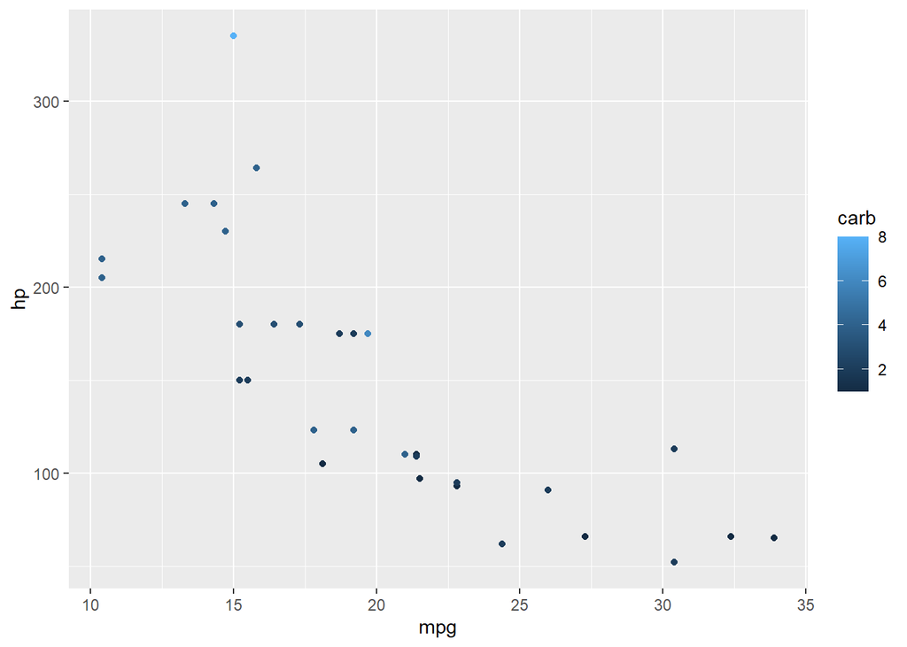

```r
ggplot(mtcars, aes(x=mpg, y=hp, color=carb))+
  geom_point()
```

### Apartado b)

En este segundo punto se podría emplear la librería dplyr, pero con la función base order se obtiene el mismo resultado ordenando de mayor a menor hp

```r
mtcars[order(mtcars$hp, decreasing=TRUE),]
```

```
##                      mpg cyl  disp  hp drat    wt  qsec vs am gear carb
## Maserati Bora       15.0   8 301.0 335 3.54 3.570 14.60  0  1    5    8
## Ford Pantera L      15.8   8 351.0 264 4.22 3.170 14.50  0  1    5    4
## Duster 360          14.3   8 360.0 245 3.21 3.570 15.84  0  0    3    4
## Camaro Z28          13.3   8 350.0 245 3.73 3.840 15.41  0  0    3    4
## Chrysler Imperial   14.7   8 440.0 230 3.23 5.345 17.42  0  0    3    4
## Lincoln Continental 10.4   8 460.0 215 3.00 5.424 17.82  0  0    3    4
## Cadillac Fleetwood  10.4   8 472.0 205 2.93 5.250 17.98  0  0    3    4
## Merc 450SE          16.4   8 275.8 180 3.07 4.070 17.40  0  0    3    3
## Merc 450SL          17.3   8 275.8 180 3.07 3.730 17.60  0  0    3    3
## Merc 450SLC         15.2   8 275.8 180 3.07 3.780 18.00  0  0    3    3
## Hornet Sportabout   18.7   8 360.0 175 3.15 3.440 17.02  0  0    3    2
## Pontiac Firebird    19.2   8 400.0 175 3.08 3.845 17.05  0  0    3    2
## Ferrari Dino        19.7   6 145.0 175 3.62 2.770 15.50  0  1    5    6
## Dodge Challenger    15.5   8 318.0 150 2.76 3.520 16.87  0  0    3    2
## AMC Javelin         15.2   8 304.0 150 3.15 3.435 17.30  0  0    3    2
## Merc 280            19.2   6 167.6 123 3.92 3.440 18.30  1  0    4    4
## Merc 280C           17.8   6 167.6 123 3.92 3.440 18.90  1  0    4    4
## Lotus Europa        30.4   4  95.1 113 3.77 1.513 16.90  1  1    5    2
## Mazda RX4           21.0   6 160.0 110 3.90 2.620 16.46  0  1    4    4
## Mazda RX4 Wag       21.0   6 160.0 110 3.90 2.875 17.02  0  1    4    4
## Hornet 4 Drive      21.4   6 258.0 110 3.08 3.215 19.44  1  0    3    1
## Volvo 142E          21.4   4 121.0 109 4.11 2.780 18.60  1  1    4    2
## Valiant             18.1   6 225.0 105 2.76 3.460 20.22  1  0    3    1
## Toyota Corona       21.5   4 120.1  97 3.70 2.465 20.01  1  0    3    1
## Merc 230            22.8   4 140.8  95 3.92 3.150 22.90  1  0    4    2
## Datsun 710          22.8   4 108.0  93 3.85 2.320 18.61  1  1    4    1
## Porsche 914-2       26.0   4 120.3  91 4.43 2.140 16.70  0  1    5    2
## Fiat 128            32.4   4  78.7  66 4.08 2.200 19.47  1  1    4    1
## Fiat X1-9           27.3   4  79.0  66 4.08 1.935 18.90  1  1    4    1
## Toyota Corolla      33.9   4  71.1  65 4.22 1.835 19.90  1  1    4    1
## Merc 240D           24.4   4 146.7  62 3.69 3.190 20.00  1  0    4    2
## Honda Civic         30.4   4  75.7  52 4.93 1.615 18.52  1  1    4    2
```

### Apartado c)

Para este apartado se añadirá una columna nueva al dataframe que mostrará el ratio solicitado para después ordenar por su observación máxima.

```r
# Se crea la columna con el ratio calculado
mtcars$mpg_sobre_wt<-mtcars$mpg/mtcars$wt

# Se selecciona la observación cuyo ratio sea el máximo de esa columna
mtcars[mtcars$mpg_sobre_wt==max(mtcars$mpg_sobre_wt),]
```

```
##               mpg cyl disp  hp drat    wt qsec vs am gear carb mpg_sobre_wt
## Lotus Europa 30.4   4 95.1 113 3.77 1.513 16.9  1  1    5    2     20.09253
```

# Pregunta 4

Antes de ir a los apartados, se carga la matriz en una nueva variable

```r
datos<-structure(c(1, 2, 3, 4, 5, 6, 7, 8, 9, 10, 11, 12, 13, 14, 15,
16, 1, 1, 1, 1, 1, 1, 1, 1, 1, 1, 1, 1, 1, 1, 1, 1, 1, 1, 1,
1, 1, 1, 1, 1, 1, 1, 1, 1, 2, 1, 1, 1, 1, 1, 1, 1, 1, 1, 1, 1,
1, 1, 1, 1, 1, 1, 1, 1, 1, 1, 1, 1, 1, 1, 3, 1, 1, 1, 1, 1, 3,
2, 1, 1, 1, 1, 1, 1, 2, 1, 4, 1, 1, 1, 1, 1, 2, 2, 1, 1, 1, 1,
2, 3, 3, 1, 2, 1, 1, 1, 1, 1, 3, 4, 1, 1, 1, 2, 3, 4, 3, 1, 2,
1, 1, 4, 1, 1, 4, 4, 1, 1), .Dim = c(16L, 8L))
```

### Apartado a)

Para este apartado se extraerá la última columna de la matriz, se convertirá en vector y se calcularán sus frecuencias relativas

```r
# Almacenar en un vector la última columna de la matriz como vector con
# transposición
s7<-as.vector(t(datos)[8,])

# Calcular las frecuencias relativas como el número de sucesos de cada tipología
# entre el total de observaciones
f_relativa<-tabulate(s7)/length(s7)

# Calcular el complementario de dicha frecuencia relativa
f_relativa_comp<-1-f_relativa

# Combinar intercalando los resultados de ambos vectores
vector_f_relativas<-c(rbind(f_relativa, f_relativa_comp))
```

### Apartado b)

En este caso, se ha de generar una función personalizada que se pueda pasar como argumento de apply y aplicarse a todas las columnas de la matriz

```r
# Definir la función siguiendo los pasos del apartado anterior, pero sin incluir
# la parte de extracción del vector y su posterior transposición
get_f_relativas <- function(vector) {

  f_relativa<-tabulate(vector, nbins = 8)/length(vector)
  f_relativa_comp<-1-f_relativa
  vector_f_relativas<-c(rbind(f_relativa, f_relativa_comp))

  return(vector_f_relativas)
}

# Almacenar en una variable el resultado de apply convirtiéndolo en matriz
matriz_frecuencias<-as.matrix(apply(datos[,-1], 2, get_f_relativas))

# Mostrar el resultado
matriz_frecuencias
```

```
##       [,1]   [,2] [,3]   [,4]   [,5]   [,6]  [,7]
##  [1,]    1 0.9375    1 0.8125 0.7500 0.6250 0.500
##  [2,]    0 0.0625    0 0.1875 0.2500 0.3750 0.500
##  [3,]    0 0.0625    0 0.0625 0.1875 0.1250 0.125
##  [4,]    1 0.9375    1 0.9375 0.8125 0.8750 0.875
##  [5,]    0 0.0000    0 0.1250 0.0000 0.1875 0.125
##  [6,]    1 1.0000    1 0.8750 1.0000 0.8125 0.875
##  [7,]    0 0.0000    0 0.0000 0.0625 0.0625 0.250
##  [8,]    1 1.0000    1 1.0000 0.9375 0.9375 0.750
##  [9,]    0 0.0000    0 0.0000 0.0000 0.0000 0.000
## [10,]    1 1.0000    1 1.0000 1.0000 1.0000 1.000
## [11,]    0 0.0000    0 0.0000 0.0000 0.0000 0.000
## [12,]    1 1.0000    1 1.0000 1.0000 1.0000 1.000
## [13,]    0 0.0000    0 0.0000 0.0000 0.0000 0.000
## [14,]    1 1.0000    1 1.0000 1.0000 1.0000 1.000
## [15,]    0 0.0000    0 0.0000 0.0000 0.0000 0.000
## [16,]    1 1.0000    1 1.0000 1.0000 1.0000 1.000
```

```r
matriz_frecuencias<-matriz_frecuencias[c(1:8),]

# Mostrar el nuevo resultado
matriz_frecuencias
```

```
##      [,1]   [,2] [,3]   [,4]   [,5]   [,6]  [,7]
## [1,]    1 0.9375    1 0.8125 0.7500 0.6250 0.500
## [2,]    0 0.0625    0 0.1875 0.2500 0.3750 0.500
## [3,]    0 0.0625    0 0.0625 0.1875 0.1250 0.125
## [4,]    1 0.9375    1 0.9375 0.8125 0.8750 0.875
## [5,]    0 0.0000    0 0.1250 0.0000 0.1875 0.125
## [6,]    1 1.0000    1 0.8750 1.0000 0.8125 0.875
## [7,]    0 0.0000    0 0.0000 0.0625 0.0625 0.250
## [8,]    1 1.0000    1 1.0000 0.9375 0.9375 0.750
```

Comentando ya los resultados, se pued ever que en la semana 1, como la sensación de ardor es en todo 1, sólo está el par 1-0, en la segunda semana ya hay más variedad con algún 2, por lo que surgen 4 valores diferentes y así va progresando hasta la última semana. Esto se ve mejor con los gráficos.

### Apartado c)

Se procede a generar el gráfico solicitado

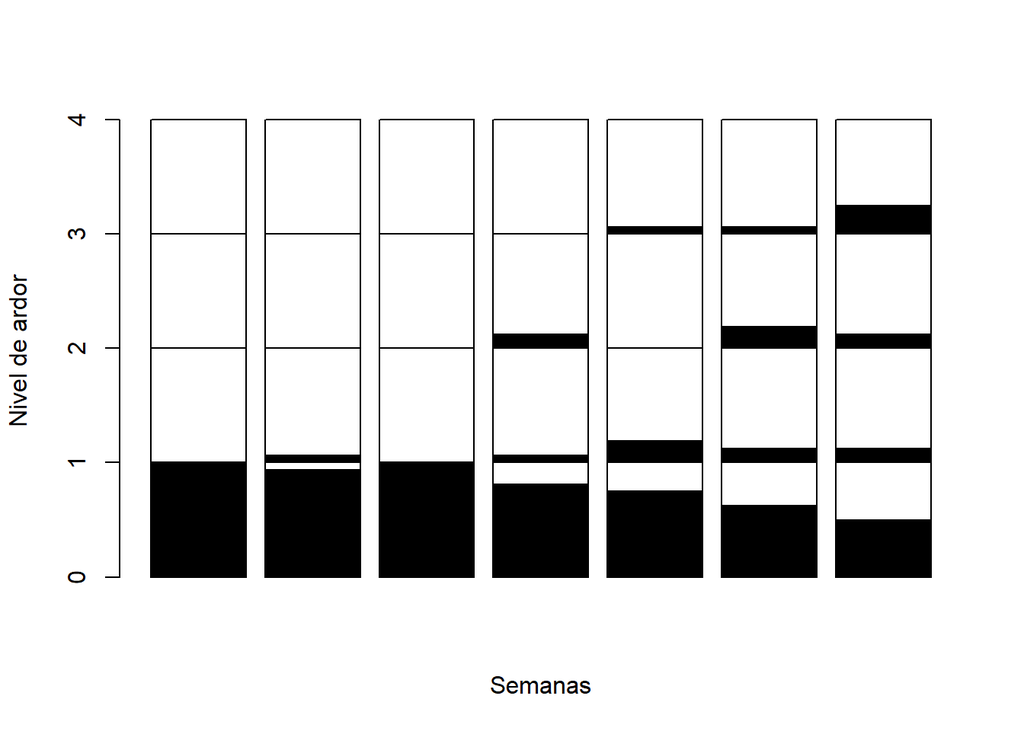

```r
barplot(matriz_frecuencias,col = c("black","white"),
        xlab = "Semanas",
        ylab = "Nivel de ardor")
```

En el eje Y se muestran los distintos niveles de ardor que hay (hasta 4) y en el eje X se encuentran las semanas. En la primera semana, todas las frecuencias están concentradas en el 1 y en la última se ve como la frecuencia (la parte negra) queda más distribuida a lo largo de todos los niveles de ardor posibles. Podemos concluir que con el tiempo el hidrogel va causando sensación de ardor a cada vez más personas.

### Apartado d)

Se incluyen en el gráfico los nuevos cambios

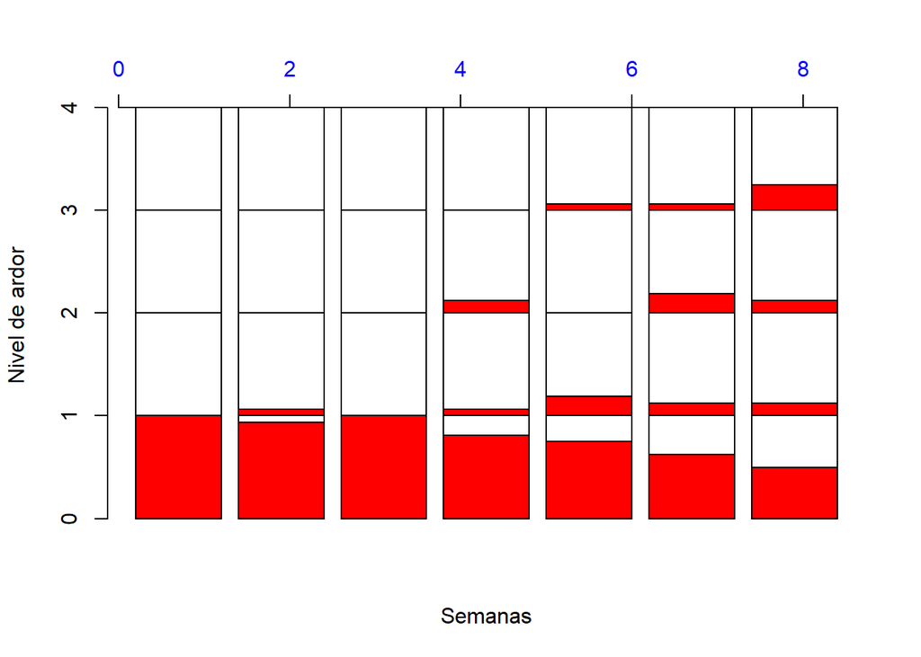

```r
barplot(matriz_frecuencias,
        col = c("red","white"),
        xlab = "Semanas",
        ylab = "Nivel de ardor")
axis(3, col="black", col.ticks="black", col.axis="blue", cex.axis=1)
```